# S5_InformeP4

Grupo 5

6/8/2021

UTEC - Universidad de Ingeniería y Tecnología

### **Estadística y Probabilidades**

#### **Estudio de la influencia de las actividades extracurriculares en el rendimiento académico de los estudiantes universitarios**

**Introducción**

A medida que crecemos tenemos la percepción de que nos falta tiempo para realizar lo que mas queremos, en el caso de los estudiantes universitarios, la presión llega a ser tan fuerte que sentimos no tener tiempo alguno para realizar alguna actividad extra a nuestras clases. Y es en ese momento donde surge el dilema del estudiante : ¿Hacer actividades extracurriculares afectaría a nuestro rendimiento académico? ¿No desperdiciaré mi tiempo?

En este estudio buscaremos encontrar una respuesta a esas preguntas y saber que tanto tiempo, en el caso sea beneficioso, debo dedicarle a las actividades extracurriculares y/o cuantas actividades curriculares debo realizar durante mis años de estudiante universitario para poder tener un promedio académico optimo.

**Importancia**

El estudio propuesto analizará la influencia de las actividades extracurriculares en el rendimiento académico de los estudiantes de UTEC. Este tema es **importante**, porque muchos de los estudiantes buscamos saber si es conveniente realizar actividades extracurriculares, si estas nos dan algún beneficio académico o si en verdad nos estaríamos perjudicando. Sea cual sea el resultado del estudio, pensamos que podría ser significativo y así podríamos impulsar que más estudiantes realicen este tipo de actividades.

**Justificación**

Nuestro proyecto puede aportar una nueva visión de como el rendimiento académico también es influenciado por las actividades extracurriculares. También buscamos ayudar al alumnado a planificar su tiempo durante el ciclo y encontrar el balance entre las actividades extracurriculares y los tiempos de estudio.

**Factibilidad**

Nosotros consideramos que el estudio es factible. Los datos que se recolectaron con las encuestas y la disposición que tuvieron los estudiantes de UTEC (nuestra población) nos permitirá llegar a buenas conclusiones.  
En el diagrama de Gantt podemos ver nuestras metas y acciones que se llevarán a cabo durante el ciclo en cada entrega, para cumplir con los objetivos del estudio y poder dar una perspectiva nueva con respecto a este tema de las actividades extracurriculares.

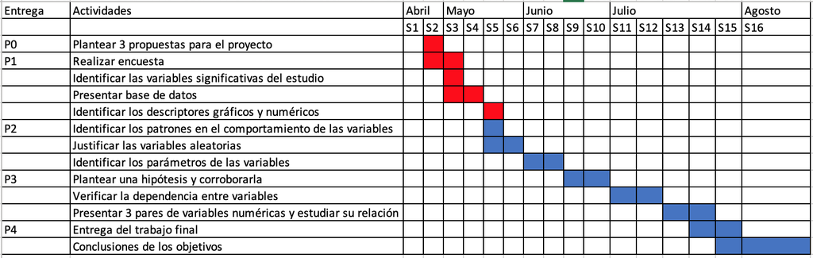

**Objetivos**

- *Objetivo General*: Averiguar el efecto que pueden llegar a tener las actividades extracurriculares en el desempeño académico de los estudiantes de UTEC.
- *Pregunta General*: ¿Cómo influyen las actividades extracurriculares en el desempeño académico de los estudiantes de UTEC?

**Marco Teórico**

**Variables**

- **Sexo**
- **Edad**
- **CicloActual**
- **HaciaActividadBool**: ¿El estudiante realizó actividades el ciclo académico pasado? (Sí / No)
- **NumActividadesRealizadas**: Cantidad de actividades extracurriculares realizadas el ciclo anterior.
- **TipoActividadRealizada**: Tipos de actividades que el estudiante realizó
- **ActividadFavorita**: Actividad a la que le dedica mayor parte de tiempo
- **TiempoDedicadoAE**: Cuántas horas diarias, en promedio, le dedicaba el estudiante a las actividades extracurriculares.
- **EscalaSentimiento**: ¿Qué tan bien te sentías al realizar la actividades extracurriculares?
- **EscalaAbrumado**: ¿Qué tan abrumado te sentías al realizar las actividades extracurriculares
- **CantidadCursos**: Cantidad de cursos llevados el ciclo académico pasado por el estudiante.
- **Promedio**: Promedio académico del ciclo anterior (número entero).
- **AbrumadoPorCursosBool**: Si el encuestado se llegó a sentir abrumado por la cantidad de cursos que llevó en el último ciclo académico. (Sí / No)
- **RetiroCursosBool**: Si es que el encuestado se llegó a retirar de algún curso del ciclo pasado. (Sí / No)
- **TiempoDedicadoCursos**: Promedio de horas diarias dedicadas al estudio de los cursos, fuera de horario de clases.

**Tabla - Tipos de Variables**

| Variables | Tipo | Restricciones |
| --- | --- | --- |
| Edad | Numérica → Discreta | Entrada numérica |
| EscalaSentimiento | Numérica → Discreta | Rango de 1 a 5 |
| EscalaAbrumado | Numérica → Discreta | Rango de 1 a 5 |
| CantidadCursos | Numérica → Discreta | Entrada numérica |
| Sexo | Categórica→ Nominal | 3 opciones diferentes, capacidad de elegir una opción |
| Edad | Numérica → Continua | Rango de 16 a 30 |
| CicloActual | Categórica → Ordinal | Rango de 1 a 10 |
| HaciaActividadBool | Categórica→ Nominal | Pregunta binaria: sí o no |
| NumActividadesRealizadas | Numérica → Discreta | Rango de 1 a 10 |
| TipoActividadRealizada | Categórica→ Nominal | 4 opciones diferentes, capacidad de elegir más de una opción |
| ActividadFavorita | Categórica→ Nominal | 4 opciones diferentes, capacidad de elegir solo una opción |
| TiempoDedicadoAE | Numérica -> Continua | Rango de 1 a 10 |
| Promedio | Numérica → Continua | Rango de 5 a 20 |
| AbrumadoPorCursosBool | Categórica→ Nominal | Pregunta binaria: sí o no |
| RetiroCursosBool | Categórica→ Nominal | Pregunta binaria: sí o no |
| TiempoDedicadoCursos | Numérica → Continua | Rango de 1 a 10 |

**Sobre la muestra**

**Entendiendo nuestra muestra: (Parámetros de estudio)** Lo primordial es saber la cantidad de alumnos que realizaron la encuesta. Lo primero que se hizo fue contactarse con Bienestar Estudiantil y para saber un estimado de la cantidad de Alumnos en UTEC. La cantidad de alumnos matriculados el ciclo anterior en UTEC fue de aproximadamente 2600 estudiantes(N). Además, el grupo decidió fijar el margen de error(e) en 5% y la confianza(z = 1.96) de 95%. Buscamos tener un estudio relevante y representativo.

Seleccionamos una confianza del 95% porque la población de UTEC es relativamente pequeña (N ~ 2600) entonces el tamaño de la muestra será alcanzable.

Para estimar el tamaño necesario estamos haciendo una suposición sensata. Estamos asumiendo que el 50% de los estudiantes de UTEC realizan alguna AE usando la siguiente formula

```
## [1] 334.8181
```

Usando estos estimados, el tamaño de nuestra muestra debe de ser de aproximadamente 335 estudiantes, numero que se logro sobrepasar en nuestra encuesta.

```
## [1] "Se encontraron 352 filas en la base de datos"
```

**Explorando nuestra data:**

Después de procesar la encuesta procedemos a buscar los insights en la data.

*Analizando el promedio académico:*

El promedio académico es una de las variables más importantes de este estudio. Se puede decir que el desempeño académico, es el foco principal de nuestro estudio, y este se mide principalmente con el promedio ponderado académico de los estudiantes en el ciclo 2020-2.

*Características de nuestra muestra:* -Promedio

¿Como se distribuye el promedio?

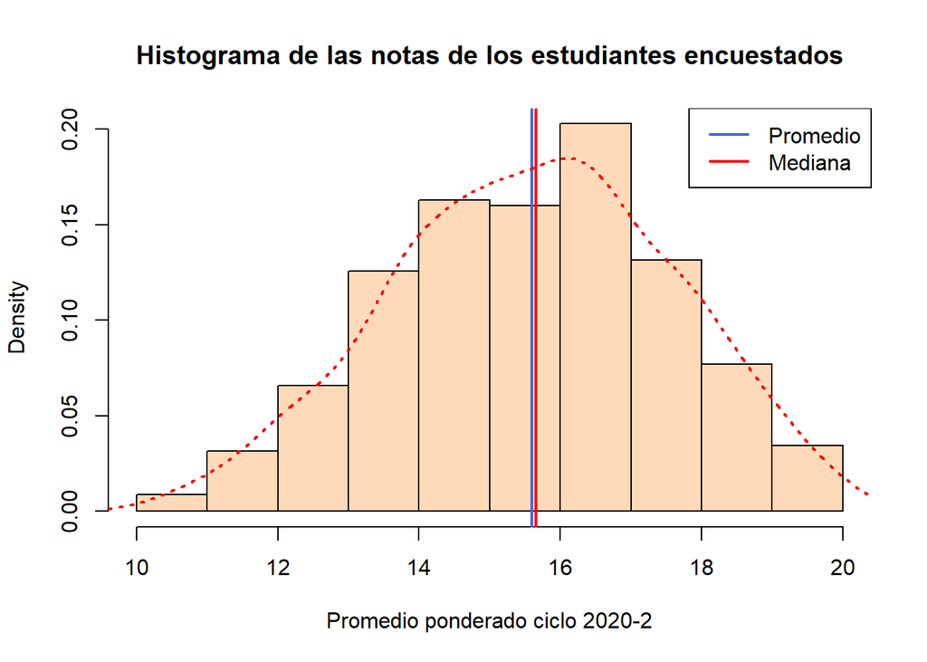

(Figura 1.1)

-Como se puede observar, la distribución del promedio de los estudiantes se asemeja a una distribución simétrica. Entonces, ¿podemos decir que se asemeja a una distribución normal? Para eso realizaremos el Shapiro test y un QQ plot :

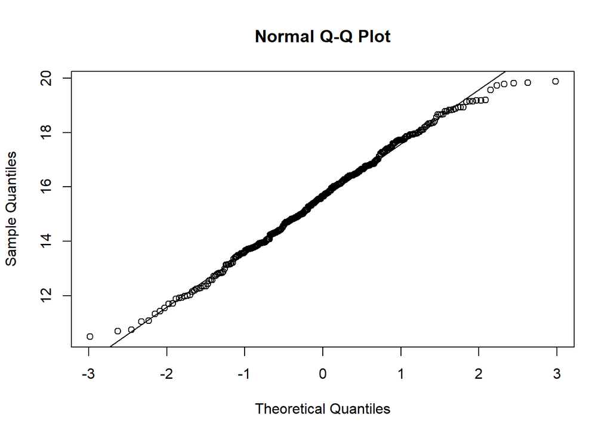

```
##
##  Shapiro-Wilk normality test
##
## data:  DFTotal$Promedio
## W = 0.99239, p-value = 0.07141
```

```
## $`Media    `
## [1] 15.6
##
## $`Mediana   `
## [1] 15.66
##
## $`Moda    `
## [1] 15.76
```

Comprobando teóricamente podemos observar que poseen media, mediana y moda muy parecidas, se confirma que si puede considerar a la distribución de la variable promedio como una distribución normal.

Usando los descriptores numéricos verificaremos los parámetros de la variable promedio.

```
## [1] "Los estudiantes que llenaron la encuesta, el ciclo pasado, tuvieron un promedio ponderado de 15.6 con un rango de 9.37 , un error tipico de: 1.98 y un coeficiente de variación de: 0.13  "
```

Después de hacer un analísis exhaustivo de la variable promedio podemos concluir lo siguente:

-El promedio de nuestros encuestados es bueno, 15 es un promedio respetable. El coeficiente de variación es menor a 30% así que podemos afirmar que la media de los promedios es representativo del conjunto de datos. Pero, ¿Qué tan seguro estamos de que la media muestral del promedio es representativa?

Para saber la representatividad de la muestra entonces sacamos los intervalos de confianza.

¿Cual es el intervalo de confianza para la media poblacional? -Intervalos de confianza para la media poblacional al 95% de confianza

```
## [1] 15.38728 15.80340
## attr(,"conf.level")
## [1] 0.95
```

- Usando la función t.test podemos encontrar los intervalos de confianza de manera indirecta. En este caso intervalo de confianza para la media poblacional es de (15.38 ,15.80). Estamos satisfechos con este intervalo de confianza para la media porque un alumno con promedio de 15.8 no se esta desempeñando académicamente mejor que un alumno con promedio 15.38.

**Preguntas explorativas:**

El estudio se enfoca en la relación de actividades extracurriculares. Lo primero que se viene a la mente es > 1. ¿Los estudiantes que realizan actividades academicas tienen un promedio mayor a 15?

-Como la media muestral es representativa al conjunto de datos entonces podemos usarla como punto de referencia para clasificar a los estudiantes como sobresalientes o no (Promedio académico > 15 = sobresaliente). Este indice sera la base de nuestras hipótesis.

- Para responder esta pregunta tenemos que dividir a los estudiantes, los que realizan Actividades Extracurriculares (AE) y los que no.

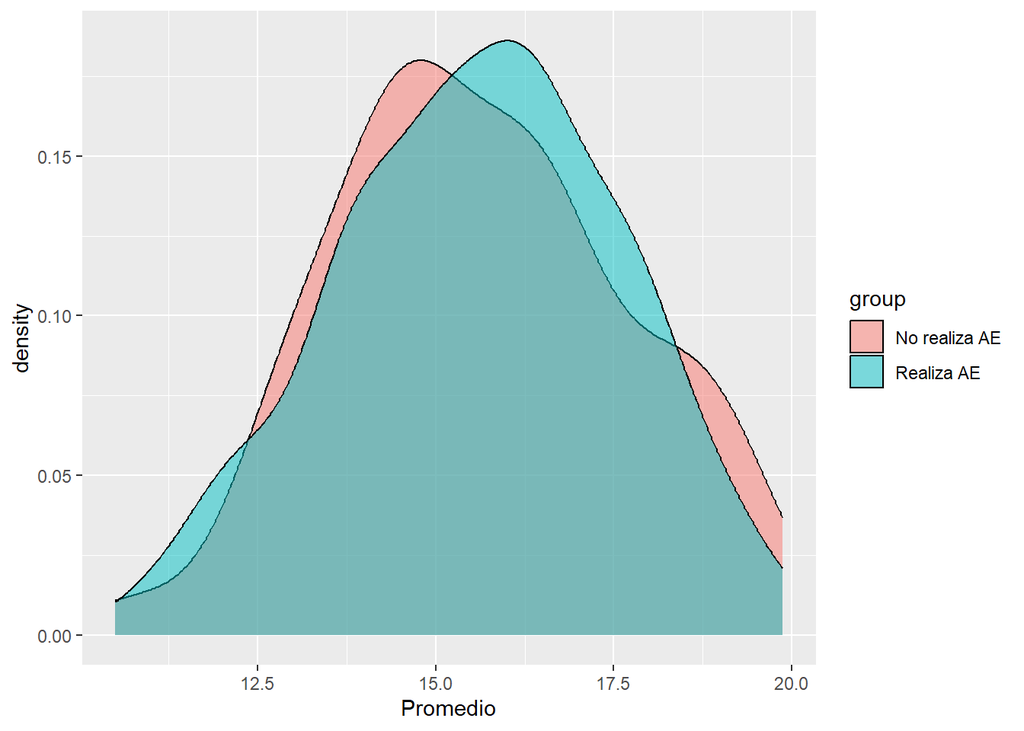

(Figura 1.2)

Este gráfico de densidad es muy interesante. Se puede ver que los que realizan AE se concentran en un promedio mayor comparado con los que no realizan AE. Algo que también se puede observar en el siguiente diagrama de cajas y bigotes (boxplot):

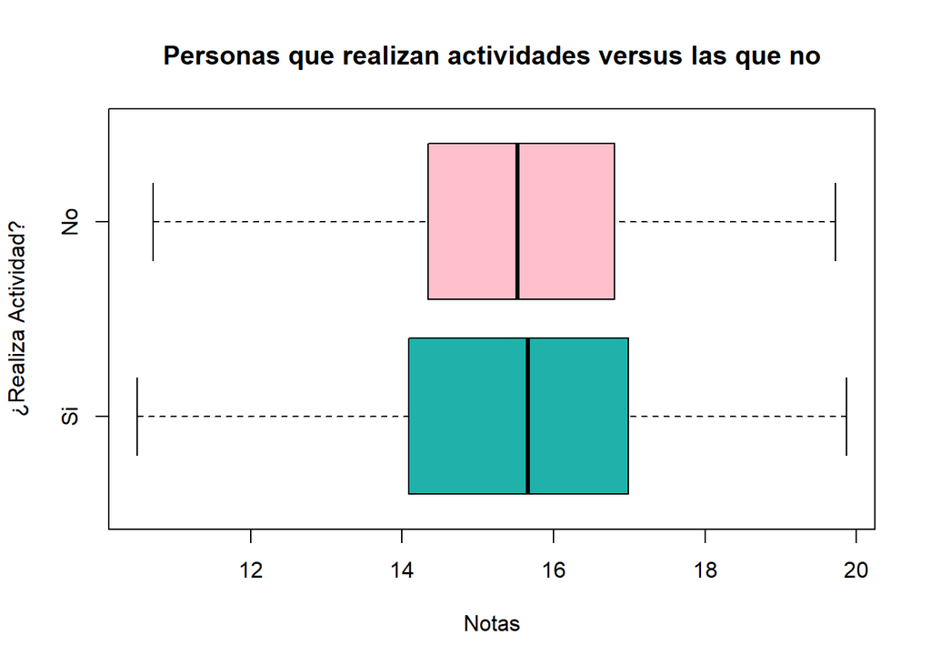

(Figura 1.3)

*Veamos más:*

- ¿Cuál es la media de los dos grupos de estudiantes?
- ¿Es esta media representativa?¿Cual es su coeficiente de variación?¿El error estándar?

```
## [1] "Los que realizan AE"
```

| Min. | 1st Qu. | Median | Mean | 3rd Qu. | Max. |
| --- | --- | --- | --- | --- | --- |
| 10.5 | 14.09 | 15.66 | 15.58 | 16.98 | 19.87 |

```
## [1] "Los que NO realizan AE"
```

| Min. | 1st Qu. | Median | Mean | 3rd Qu. | Max. |
| --- | --- | --- | --- | --- | --- |
| 10.71 | 14.34 | 15.52 | 15.62 | 16.8 | 19.72 |

```
## [1] "El coeficiente de variación de los alumnos que realizan AE: 0.13 que no varia mucho con respecto a los que NO realizan AE: 0.13 Los errores tipicos tambien se parecen mucho 1.98 comparado a 2.04"
```

***Observaciones:**

*¿Porqué pasa esto?*

Ya vimos que, aparentemente no hay una diferencia clara entre los que realizan AE y los que NO realizan AE comparando su promedio académico. Mas adelante con las pruebas de hipotésis se analízará. Sin embargo, podemos explorar mas la data para ver si hay AE que ayudan a los estudiantes. La siguiente pregunta lógica sería:

*¿Cuál es el peso de la evidencia que ofrece la muestra?*

**Prueba de Hipótesis 1**

> $H_{o}$: La media muestral del promedio académico los estudiantes que realizan AE es menor que la media poblacional X < 15

> $H_{1}$: La media muestral del promedio academico de los estudiantes que realizan AE es mayor que la media poblacional X >= 15

```
## [1] 0.01571883
```

```
## [1] -1.959964
```

```
## [1] TRUE
```

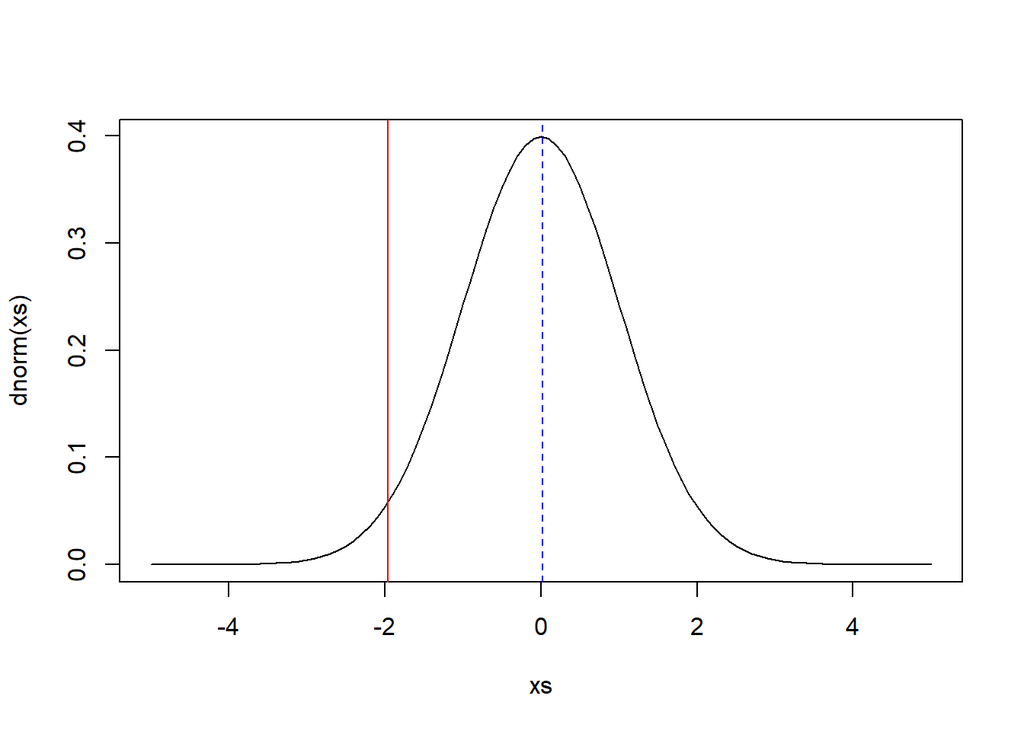

La gráfica nos indica que el zcrítico es menor al zobservado. Lo que nos hace pensar que no podemos rechazar hipotesis nula. Pero necesitamos ver el p-value para saber la significancia de la hipótesis.

```
## [1] 0.5062706
```

Con un p value de 0.5 decimos que retenemos la hipótesis nula.

La siguiente pregunta lógica es:

*¿Qué estudiantes, de acuerdo a la actividad académica que realiza, tienen promedio mayor a 15?*

Para responder a esta pregunta primero tenemos que separar a los estudiantes que realizan AE en grupos. Estos grupos son los diferentes tipos de AE que realizan. Dentro de las AE existen diferentes tipos

```
## [1] "Actividades de Ocio"            "Actividades Académicas"
## [3] "Emprendimiento/Trabajo"         "Actividades Deportivas/Físicas"
```

Luego de separar a los estudiantes del grupo vamos a ver la cantidad de alumnos en cada grupo para saber las proporciones.

```
## [1] "Contamos con  94 estudiantes que relizan actividades de Ocio"
```

```
## [1] "Contamos con  96 estudiantes que realizan actividades académica.s"
```

```
## [1] "Contamos con  37 estudiantes que trabajan o realizan emprendimientos."
```

```
## [1] "Contamos con  68 estudiantes que relizan actividades deportivas/físicas."
```

Luego de saber las proporciones vamos entender la significancia de la media. Para esto vamos a ver la forma de su distribución:

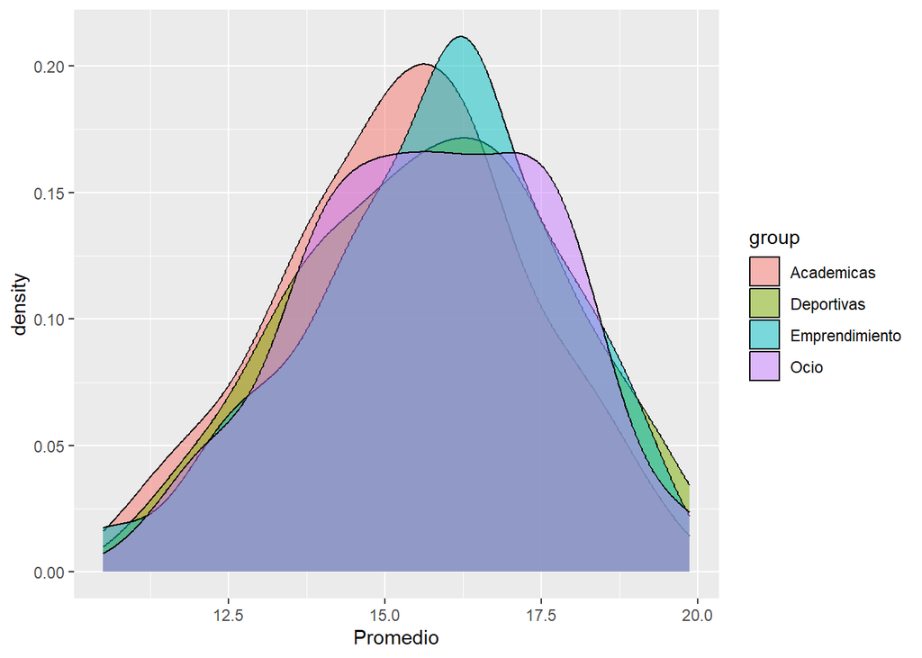

Haremos un QQTest para saber si podemos modelar estas distribuciones como normales.

```
##
##  Shapiro-Wilk normality test
##
## data:  AcOci$Promedio
## W = 0.98392, p-value = 0.3042
```

```
##
##  Shapiro-Wilk normality test
##
## data:  AcAca$Promedio
## W = 0.99091, p-value = 0.7611
```

```
##
##  Shapiro-Wilk normality test
##
## data:  AcEmp$Promedio
## W = 0.97285, p-value = 0.4909
```

```
##
##  Shapiro-Wilk normality test
##
## data:  AcDep$Promedio
## W = 0.98578, p-value = 0.6333
```

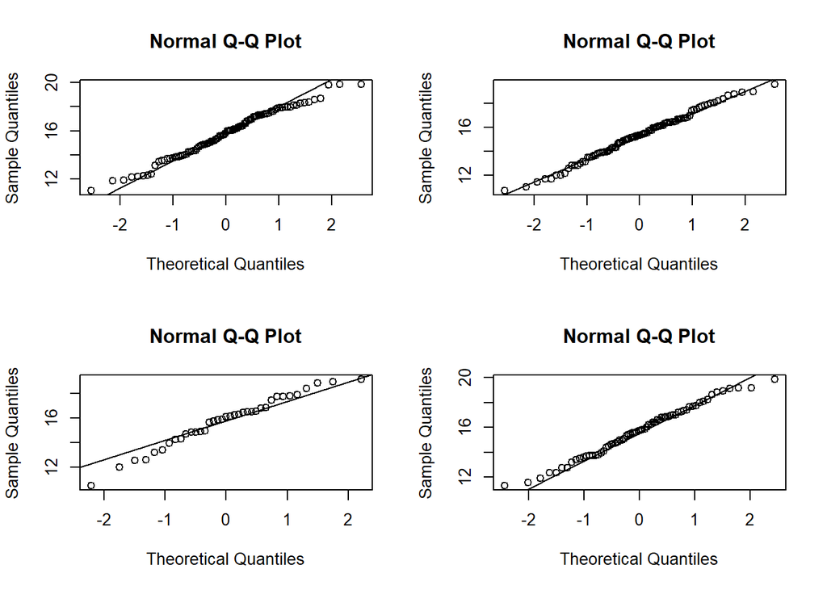

Usando el grafíco QQ podemos ver la diferencia entre la distribucion de probabilidad de una población, en este caso el tipo de actividad, y la distribución que se quiere aproximar, en este caso la normal.

Se puede concluir de que los 4 promedios de los 4 tipos de actividades extracurriculares se pueden modelar como una distribución normal.

El análisis de esta variable nos permitirá responder si existe una actividad donde los estudiantes tengan un promedio mayor a 15 (siendo 15 significativo por lo expuesto anteriormente).

Ahora que sabemos como modelar la variable haremos una primera comparación. Usando un barplot se comparará el promedio entre todas las actividades.

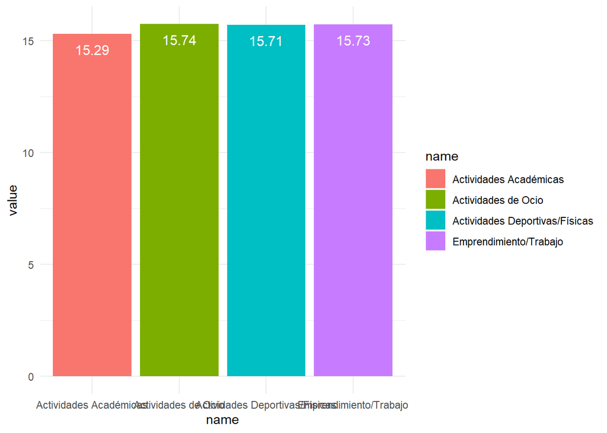

*Pero ¿Es esto cierto?.*

Puede ser medio sospechoso puesto que, se puede pensar, hacer un emprendimiento y/o trabajar requiere mucho tiempo. Se necesita mas preguntas para confirmar esto. Las dos preguntas claves son:

*¿Qué porcentaje de los encuestados trabaja o tiene un emprendimiento?* *¿El tiempo que se dedica a los estudios influye mas que las AE que se realicen?*

La segunda pregunta la dejaremos para mas adelante. Ahora analizaremos la primera pregunta puesto que guarda mas relevancia con esta parte del estudio.

*¿Qué porcentaje de los encuestados trabaja o tiene un emprendimiento?*

[output not shown]

Para esto se plantean las siguientes Hipotesis nulas y Hipotesis Alternativas para cada tipo de actividad que los estudiantes puedan realizar:

**Pruebas de Hipótesis 2**

> $H_{o_1}$: Los estudiantes que realizan actividades deportivas tienen una media del promedio menor a 15.

> $H_{o_2}$: Los estudiantes que realizan actividades de ocio tienen una media del promedio menor a 15

> $H_{o_3}$: Los estudiantes que realizan actividades academicas tienen una media del promedio menor a 15

> $H_{o_4}$: Los estudiantes que realizan actividades de emprendimiento/Trabajo tienen una media del promedio menor a 15

> $H_{1_1}$: Los estudiantes que realizan actividades deportivas tienen una media del promedio mayor o igual a 15

> $H_{1_2}$: Los estudiantes que realizan actividades de ocio tienen una media del promedio mayor o igual a 15

> $H_{1_3}$: Los estudiantes que realizan actividades academica tienen una media del promedio mayor o igual a 15

> $H_{1_4}$: Los estudiantes que realizan actividades de emprendimiento/trabajo tienen una media del promedio mayor o igual a 15

Las variables involucradas son: -Promedio -ActividadFavorita

Primero calculamos los de Intervalos de Confianza del promedio académico.

Calcularemos los IC de media para la variable “Promedio” en dflosQueHacenAE con 95% de nivel de confianza

```
## ( 15.35776 , 15.80936 )
```

Usaremos una distribución normal debido al tamano de muestra que es grande y la desviacion es conocida para calcular el punto donde comienza la región de rechazo de cada tipo de AE.

ZcritA - Para Acdemicas ZcritO - Para Ocio ZcritD - Para Deportivas ZcritE - Para Emprendimiento

Ahora debemos hallar el estadistico para ver si este cae en la region de rechazo o no

```
## [1] FALSE
```

```
## [1] TRUE
```

```
## [1] TRUE
```

```
## [1] TRUE
```

| Tipo de Actividad | N | Sigma | Xbarra | Zcrit | Pvalue | Resultado Prueba |  |  |
| --- | --- | --- | --- | --- | --- | --- | --- | --- |
| **Academica** | 96 | 1.9304 | 15.2904 | 15.3440 | 0.07 | FALSE |  |  |
| **Deportivas** | 68 | 2.0440 | 15.7079 | 15.4077 | 0.0021 | TRUE |  |  |
| **Ocio** | 94 | 1.9595 | 15.7359 | 15.3324 | 0.0001 | TRUE |  |  |
| **Emprendimiento** | 37 | 2.0264 | 15.7283 | 15.5479 | 0.0143 | TRUE |  |  |

Para las actividades academicas, como el estadistico no cae en la region de rechazo, no tenemos la suficiente evidencia para rechazar la hipotesis nula.

Para las actividades de Ocio, como el estadistico cae en la region de rechazo, tenemos la suficiente evidencia para rechazar la hipotesis nula.

Para las actividades deportivas, como el estadistico cae en la region de rechazo, tenemos la suficiente evidencia para rechazar la hipotesis nula.

Para las actividades de emprendimiento, como el estadistico cae en la region de rechazo, tenemos la suficiente evidencia para rechazar la hipotesis nula.

Para corroborar lo antes visto se sacan los p values

La influencia de las Actividades Extracurriculares en el desempeño académico todavía no esta clara. Un factor importante que todavia no tomamos en cuenta es el tiempo que cada estudiante le dedica a las AE y su promedio

Ahora, tocaría plantear una relación entre el promedio y el tiempo dedicado tanto a las actividades extracurriculares como a los estudios. ¿Dependerá de algún tipo de actividad obtener mejor promedio? eso lo demostraremos a continuación:

**Prueba de Hipótesis 3**

> $H_o$: Los estudiantes cuyo tiempo dedicado a las AE es mayor que su tiempo dedicado a los cursos, tienen un tiempo de estudio dedicado a los cursos menor que 4 horas.

> $H_1$: Los estudiantes cuyo tiempo dedicado a las AE es mayor que su tiempo dedicado a los cursos, tienen un tiempo de estudio dedicado a los cursos mayor o igual que 4 horas.

Creamos un data frame con los estudiante que tiene un tiempo dedicado a las AE mayor que el tiempo dedicado a los cursos

Se saca la cantidad de muestra de nuestro publico a analizar asi como el sigma correspondiente. Con esto sabemos que es una normal y lo usamos para hallar el Zcrit

Ahora sacamos el estadistico para saber si esta en la region de rechazo o no

```
## [1] FALSE
```

Para corrobora se saca el Pvalue

```
## [1] 1
```

Para las personas que tienen un tiempo dedicado mayor que su tiempo dedicado a curso,como el estadistico no cae en la region de rechazo, no tenemos la suficiente evidencia para rechazar la hipotesis nula.

> $H_o$: Los estudiantes cuyo tiempo dedicado a las AE es mayor que su tiempo dedicado a los cursos, tienen un tiempo de estudio dedicado a los cursos menor que 4 horas.

> $H_1$: Los estudiantes cuyo tiempo dedicado a las AE es mayor que su tiempo dedicado a los cursos, tienen un tiempo de estudio dedicado a los cursos mayor o igual que 4 horas.

*Preguntas Predictivas*

> ¿Se puede decir que hay una correlacion entre horas a dedicadas a las actividades deportivas y el promedio academico?

Nosotros partimos de la presuncion que las personas que hacen ejercicio tienen mejores notas.

```r
diDE  <- filter(DFTotal, ActividadFavorita == "Actividades Deportivas/Físicas" )
```

Para ver si existe algo interesante primero vemos en el diagrama de puntos que como se comporta la recta.

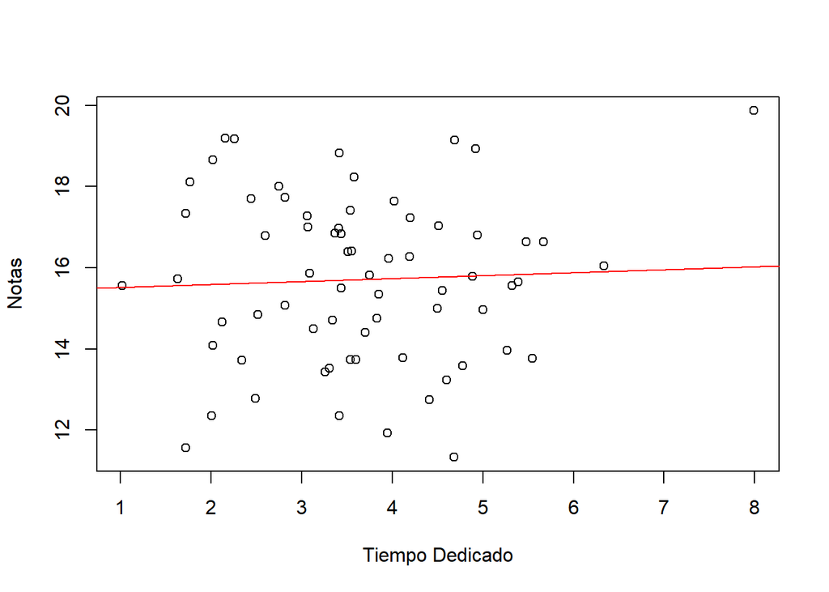

```r
RectaDeRegresion<-lm(diDE$Promedio~diDE$TiempoDedicadoAE)
plot(diDE$Promedio~diDE$TiempoDedicadoAE, xlab = "Tiempo Dedicado", ylab = "Notas")
abline(RectaDeRegresion, col="red")
```

```r
cor(diDE$Promedio,diDE$TiempoDedicadoAE)
```

```
## [1] 0.04579092
```

La correlación no es muy fuerte y eso es debido a la disperción de los datos. Sigamos viendo

```r
summary(RectaDeRegresion)
```

```
##
## Call:
## lm(formula = diDE$Promedio ~ diDE$TiempoDedicadoAE)
##
## Residuals:
##     Min      1Q  Median      3Q     Max
## -4.4536 -1.5900  0.0704  1.3791  3.8425
##
## Coefficients:
##                       Estimate Std. Error t value Pr(>|t|)
## (Intercept)           15.43890    0.76431  20.200   <2e-16 ***
## diDE$TiempoDedicadoAE  0.07366    0.19780   0.372    0.711
## ---
## Signif. codes:  0 '***' 0.001 '**' 0.01 '*' 0.05 '.' 0.1 ' ' 1
##
## Residual standard error: 2.057 on 66 degrees of freedom
## Multiple R-squared:  0.002097,   Adjusted R-squared:  -0.01302
## F-statistic: 0.1387 on 1 and 66 DF,  p-value: 0.7108
```

Vamos a ver si nuestros modelos son significativos

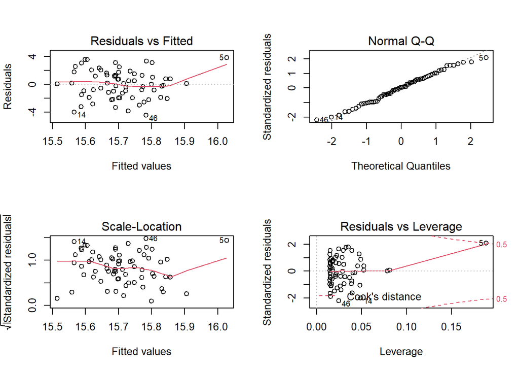

```r
par(mfrow=c(2,2))
plot(RectaDeRegresion)
```

Como podemos ver en los gráficos de residuales nuestro modelo no predice de forma significativa las notas de el tiempo de los deportistas y su promedio académico.

```r
names(AcAca)
```

```
##  [1] "X"                        "Sexo"
##  [3] "Edad"                     "CicloActual"
##  [5] "HaciaActividadBool"       "NumActividadesRealizadas"
##  [7] "TipoActividadRealizada"   "ActividadFavorita"
##  [9] "TiempoDedicadoAE"         "EscalaSentimiento"
## [11] "EscalaAbrumado"           "CantidadCursos"
## [13] "Promedio"                 "AbrumadoPorCursosBool"
## [15] "RetiroBool"               "TiempoDedicadoCursos"
```

> ¿Qué tipo de actividad extracurricular te beneficia más en tu desempeño académico?

**Actividades Academicas**

```r
regresi1 <- lm(Promedio~ EscalaAbrumado + EscalaSentimiento +TiempoDedicadoAE + TiempoDedicadoCursos, data = AcAca)
summary(regresi1)
```

```
##
## Call:
## lm(formula = Promedio ~ EscalaAbrumado + EscalaSentimiento +
##     TiempoDedicadoAE + TiempoDedicadoCursos, data = AcAca)
##
## Residuals:
##     Min      1Q  Median      3Q     Max
## -4.5248 -1.3929  0.0469  1.2229  4.2630
##
## Coefficients:
##                      Estimate Std. Error t value Pr(>|t|)
## (Intercept)          15.39913    1.45146  10.609   <2e-16 ***
## EscalaAbrumado        0.07472    0.16442   0.454    0.651
## EscalaSentimiento    -0.05899    0.24254  -0.243    0.808
## TiempoDedicadoAE      0.02431    0.14578   0.167    0.868
## TiempoDedicadoCursos -0.04235    0.18919  -0.224    0.823
## ---
## Signif. codes:  0 '***' 0.001 '**' 0.01 '*' 0.05 '.' 0.1 ' ' 1
##
## Residual standard error: 1.968 on 91 degrees of freedom
## Multiple R-squared:  0.003995,   Adjusted R-squared:  -0.03979
## F-statistic: 0.09125 on 4 and 91 DF,  p-value: 0.985
```

Con las personas que realizan actividades academicas no podemos concluir nada, el p value nos dice que no estamos significativamente positivos y el coeficiente de determinación el modelo no puede explicar la variabilidad. Veremos si el tiempo dedicado a esta actividad tiene una relación con el promedio de estos estudiantes.

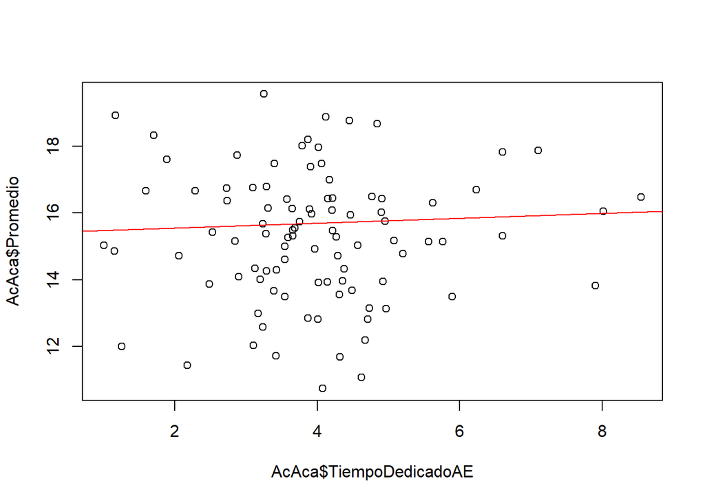

```r
plot(AcAca$Promedio~AcAca$TiempoDedicadoAE)
abline(regresi1, col="red")
```

Como se pude ver, la línea de regresión es no tiene una pendiente pronunciada. Podemos concluir que no hay una relación entre los estudiantes que realizan actividades académicas y su tiempo con su promedio. **Actividades Deportivas**

```r
regresi2 <- lm(Promedio~ EscalaAbrumado + EscalaSentimiento +TiempoDedicadoAE + TiempoDedicadoCursos, data = AcDep)
summary(regresi2)
```

```
##
## Call:
## lm(formula = Promedio ~ EscalaAbrumado + EscalaSentimiento +
##     TiempoDedicadoAE + TiempoDedicadoCursos, data = AcDep)
##
## Residuals:
##     Min      1Q  Median      3Q     Max
## -4.2337 -1.3768  0.0937  1.3105  4.0932
##
## Coefficients:
##                      Estimate Std. Error t value Pr(>|t|)
## (Intercept)          17.49716    1.75335   9.979 1.36e-14 ***
## EscalaAbrumado       -0.45421    0.23309  -1.949   0.0558 .
## EscalaSentimiento     0.05359    0.31854   0.168   0.8669
## TiempoDedicadoAE      0.08654    0.20068   0.431   0.6678
## TiempoDedicadoCursos -0.33960    0.19325  -1.757   0.0837 .
## ---
## Signif. codes:  0 '***' 0.001 '**' 0.01 '*' 0.05 '.' 0.1 ' ' 1
##
## Residual standard error: 1.993 on 63 degrees of freedom
## Multiple R-squared:  0.1062, Adjusted R-squared:  0.04944
## F-statistic: 1.871 on 4 and 63 DF,  p-value: 0.1265
```

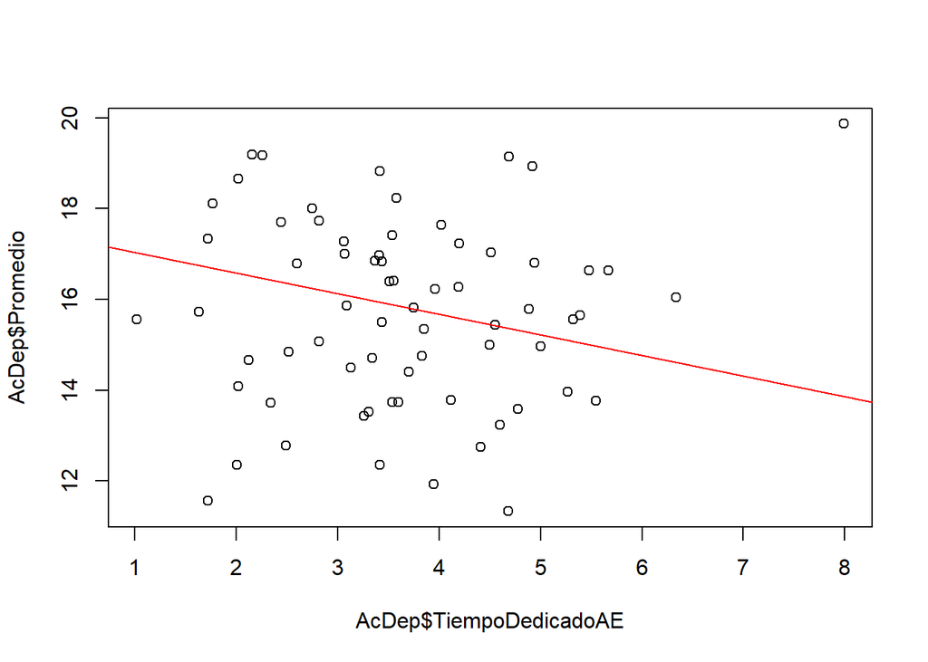

```r
plot(AcDep$Promedio~AcDep$TiempoDedicadoAE)
abline(regresi2, col="red")
```

**Actividades Emprendimientos**

```r
regresi1 <- lm(Promedio~ EscalaAbrumado + EscalaSentimiento +TiempoDedicadoAE + TiempoDedicadoCursos, data = AcEmp)
summary(regresi1)
```

```
##
## Call:
## lm(formula = Promedio ~ EscalaAbrumado + EscalaSentimiento +
##     TiempoDedicadoAE + TiempoDedicadoCursos, data = AcEmp)
##
## Residuals:
##     Min      1Q  Median      3Q     Max
## -4.5167 -0.6993  0.2205  0.9769  2.8775
##
## Coefficients:
##                      Estimate Std. Error t value Pr(>|t|)
## (Intercept)          17.33795    2.69259   6.439 3.06e-07 ***
## EscalaAbrumado        0.07254    0.29130   0.249    0.805
## EscalaSentimiento    -0.60723    0.42766  -1.420    0.165
## TiempoDedicadoAE     -0.19964    0.21937  -0.910    0.370
## TiempoDedicadoCursos  0.36624    0.25410   1.441    0.159
## ---
## Signif. codes:  0 '***' 0.001 '**' 0.01 '*' 0.05 '.' 0.1 ' ' 1
##
## Residual standard error: 1.977 on 32 degrees of freedom
## Multiple R-squared:  0.1543, Adjusted R-squared:  0.04856
## F-statistic: 1.459 on 4 and 32 DF,  p-value: 0.2376
```

**Actividades Ocio**

```r
regresi1 <- lm(Promedio~ EscalaAbrumado + EscalaSentimiento +TiempoDedicadoAE + TiempoDedicadoCursos, data = AcOci)
summary(regresi1)
```

```
##
## Call:
## lm(formula = Promedio ~ EscalaAbrumado + EscalaSentimiento +
##     TiempoDedicadoAE + TiempoDedicadoCursos, data = AcOci)
##
## Residuals:
##     Min      1Q  Median      3Q     Max
## -4.2884 -1.4981  0.0239  1.3700  4.1955
##
## Coefficients:
##                      Estimate Std. Error t value Pr(>|t|)
## (Intercept)          17.67507    1.71180  10.325   <2e-16 ***
## EscalaAbrumado        0.24450    0.19212   1.273    0.206
## EscalaSentimiento    -0.34155    0.26850  -1.272    0.207
## TiempoDedicadoAE     -0.22102    0.17559  -1.259    0.211
## TiempoDedicadoCursos -0.03255    0.17085  -0.191    0.849
## ---
## Signif. codes:  0 '***' 0.001 '**' 0.01 '*' 0.05 '.' 0.1 ' ' 1
##
## Residual standard error: 1.94 on 89 degrees of freedom
## Multiple R-squared:  0.0623, Adjusted R-squared:  0.02015
## F-statistic: 1.478 on 4 and 89 DF,  p-value: 0.2155
```

Como podemos ver en los otras actividades no tienen una significancia importante en nuestros modelos. Por lo tanto no podemos decir que nuestros modelos de regresión son significativos.

**Reflexiones finales**

- Según todos los indicios vistos en el análisis podemos concluir que no existe una relación directa entre las Actividades Extracurriculares y el desempeño académico.
- Es importante mencionar que en este estudio el desempeño académico se midió con el promedio de los estudiantes. Sin embargo, el desempeño de un estudiante también se puede medir con el envolvimiento con su comunidad y no solamente con sus notas.

-Tampoco se encontró una relación entre el tiempo que le dedicas al estudio y el promedio académico, esto fue lo más sorprendente del estudio.

**Bibliografía**

> Terenzini, P., Pascarella, E. & Blimling, G. (1999). Students´ Out of class Experiences and their Influence on Learning and Cognitive Development. En Journal of College Student Development, 40, 5, pp. 610 – 623.